# 基本資料分析（EDA)

```python
import matplotlib.pyplot as plt
from matplotlib.font_manager import FontProperties
winfont01 = FontProperties(fname=r"c:\windows\fonts\simsun.ttc", size=12)
winfont02 = FontProperties(fname=r"c:\windows\fonts\kaiu.ttf", size=12)

plt.rcParams['font.sans-serif'] = ['Microsoft JhengHei']  # 設定字型為微軟正黑體
plt.rcParams['axes.unicode_minus'] = False                # 解決負號顯示問題

macfont = FontProperties(fname="/Library/Fonts/Arial Unicode.ttf", size=10)
```

```python
# 抓資料先!!
import sqlite3
import pandas as pd

DB_FILE = "D:/NTPU_class/paper/code/mobile01_clawler/ntpu_paper.sqlite"

conn = sqlite3.connect(DB_FILE)

df_eda = pd.read_sql_query("""
    -- A) 留言評分：comment_id 有值 → 每個 comment 取最新
    SELECT
        e.comment_id,
        e.level,
        e.created_at AS eval_created_at,
        e.strategy_power,
        e.strategy_emotion,
        e.strategy_blame,
        e.score_fear,
        e.score_obligation,
        e.score_guilt,
        e.score_overall,
        e.main_strategy,
        e.main_strategy_detail,
        e.pua_source,
        e.confidence,
        e.model_name,
        e.model_version,
        e.knowledge_base,
        e.article_id,
        e.link_id
    FROM eb_evaluation e
    JOIN (
        SELECT comment_id, MAX(created_at) AS max_created_at
        FROM eb_evaluation
        WHERE comment_id IS NOT NULL
        GROUP BY comment_id
    ) latest_c
      ON e.comment_id = latest_c.comment_id
     AND e.created_at = latest_c.max_created_at

    UNION ALL

    -- B) 主文評分：comment_id 為空 → 每篇 article 取最新
    SELECT
        e.comment_id,
        e.level,
        e.created_at AS eval_created_at,
        e.strategy_power,
        e.strategy_emotion,
        e.strategy_blame,
        e.score_fear,
        e.score_obligation,
        e.score_guilt,
        e.score_overall,
        e.main_strategy,
        e.main_strategy_detail,
        e.pua_source,
        e.confidence,
        e.model_name,
        e.model_version,
        e.knowledge_base,
        e.article_id,
        e.link_id
    FROM eb_evaluation e
    JOIN (
        SELECT article_id, MAX(created_at) AS max_created_at
        FROM eb_evaluation
        WHERE comment_id IS NULL
        GROUP BY article_id
    ) latest_a
      ON e.article_id = latest_a.article_id
     AND e.created_at = latest_a.max_created_at
    WHERE e.comment_id IS NULL
""", conn)


conn.close()
```

```python
df_eda
```

|  | comment_id | level | eval_created_at | strategy_power | strategy_emotion | strategy_blame | score_fear | score_obligation | score_guilt | score_overall | main_strategy | main_strategy_detail | pua_source | confidence | model_name | model_version | knowledge_base | article_id | link_id |
| --- | --- | --- | --- | --- | --- | --- | --- | --- | --- | --- | --- | --- | --- | --- | --- | --- | --- | --- | --- |
| 0 | 6923bf32af113796ec890f88 | 2 | 2025-12-03 10:20:11 | 3.0 | 4.0 | 2.0 | 1.0 | 2.0 | 0.0 | 3.0 | emotion | 混合型情緒操控（使用情感勒索和指責） | family | 1.0 | mistral | latest | pua_db, healthy_communication_db, social_comme... | 68fce9b6af1137205015fd06 | 68f87edcaf1137700cb26e94 |
| 1 | 6923bf32af113796ec890f89 | 2 | 2025-12-03 10:20:14 | 0.0 | 2.0 | 2.0 | 1.0 | 5.0 | 3.0 | 3.0 | emotion | 強調自己要照顧父母，並提及怕出事件如昨天的新聞（僅是所引用的文字中的一部分）以施加罪愧或恐懼感 | family | 0.8 | mistral | latest | pua_db, healthy_communication_db, social_comme... | 68fce9b6af1137205015fd06 | 68f87edcaf1137700cb26e94 |
| 2 | 6923bf32af113796ec890f8a | 2 | 2025-12-03 10:20:17 | 5.0 | 4.0 | 5.0 | 3.0 | 5.0 | 5.0 | 4.0 | power | 使用控制言論（「你趕快去生小孩...」）來壓迫女性，並擬近自己的權力（通過控制她的孩子和家人... | family | 1.0 | mistral | latest | pua_db, healthy_communication_db, social_comme... | 68fce9b6af1137205015fd06 | 68f87edcaf1137700cb26e94 |
| 3 | 6923bf32af113796ec890f8b | 2 | 2025-12-03 10:20:20 | 0.0 | 4.0 | 3.0 | 2.0 | 1.0 | 1.0 | 3.0 | emotion | 情緒操控，使用情感哀求、指責、壓力語言等方式來勒索 | family | 1.0 | mistral | latest | pua_db, healthy_communication_db, social_comme... | 68fce9b6af1137205015fd06 | 68f87edcaf1137700cb26e94 |
| 4 | 6923bf32af113796ec890f98 | 2 | 2025-12-04 20:34:51 | 0.0 | 0.0 | 0.0 | 0.0 | 0.0 | 0.0 | 0.0 | none | 無勒索言論 | online | 1.0 | mistral | latest | pua_db, healthy_communication_db, social_comme... | 68fcea01af11377624f11edb | 68f87edcaf1137700cb26e96 |
| ... | ... | ... | ... | ... | ... | ... | ... | ... | ... | ... | ... | ... | ... | ... | ... | ... | ... | ... | ... |
| 10695 | None | 1 | 2025-11-24 19:26:42 | 0.0 | 2.0 | 0.0 | 0.0 | 1.0 | 0.0 | 2.0 | emotion | Expressing personal preference and sharing enj... | online | 0.8 | mistral | latest | pua_db | 6923413cdbeaa944f0dd8399 | 69220b00dbeaa9654682a2f3 |
| 10696 | None | 1 | 2025-11-24 19:26:49 | 0.0 | 1.0 | 0.0 | 2.0 | 1.0 | 0.0 | 3.0 | emotion | 引起懷疑與不安，讓使用者考慮是否使用該網站 | online | 0.8 | mistral | latest | pua_db | 69234149dbeaa944f0dd839a | 69220b00dbeaa9654682a2f4 |
| 10697 | None | 1 | 2025-11-24 19:26:56 | 3.0 | 4.0 | 1.0 | 3.0 | 4.0 | 2.0 | 3.6 | emotion | 使用情感哀求的方式請求帮助，並暗示存在不斷逃跑犯人的背景 | online | 0.8 | mistral | latest | pua_db | 69234156dbeaa944f0dd839b | 69220b00dbeaa9654682a2f5 |
| 10698 | None | 1 | 2025-11-24 19:27:03 | 1.0 | 3.0 | 0.0 | 0.0 | 4.0 | 0.0 | 3.0 | emotion | 使用感激不盡的表達方式勸誘對象完成要求 | online | 0.8 | mistral | latest | pua_db | 69234163dbeaa944f0dd839c | 69220b00dbeaa9654682a2f6 |
| 10699 | None | 1 | 2025-11-24 19:27:10 | 0.0 | 3.0 | 0.0 | 0.0 | 0.0 | 0.0 | 3.0 | emotion | 建議檢視電影，不具有強制或罪责性勒索元素 | online | 0.8 | mistral | latest | pua_db | 69234171dbeaa944f0dd839d | 69220b00dbeaa9654682a2f7 |

10700 rows × 19 columns

```python
df_eda.columns
```

```
Index(['comment_id', 'level', 'eval_created_at', 'strategy_power',
       'strategy_emotion', 'strategy_blame', 'score_fear', 'score_obligation',
       'score_guilt', 'score_overall', 'main_strategy', 'main_strategy_detail',
       'pua_source', 'confidence', 'model_name', 'model_version',
       'knowledge_base', 'article_id', 'link_id'],
      dtype='object')
```

```python
# 切一下資料
df_main = df_eda[df_eda['level'] == 1]   # 主文（Level 1）
df_reply = df_eda[df_eda['level'] == 2]  # 主文＋評論（Level 2）
print("主文筆數:", df_main.shape[0])
print("評論筆數:", df_reply.shape[0])
print("總筆數:", df_eda.shape[0])
```

```
主文筆數: 1368
評論筆數: 9332
總筆數: 10700
```

### 已經有針對main_strategy 不是唯一數值的部分 再丟回去跑一次 ex：emotion/blame

```python
categorical_cols = ['main_strategy', 'pua_source']
numeric_cols = ['strategy_power', 'strategy_emotion', 'strategy_blame', 'score_fear', 'score_obligation', 'score_guilt', 'score_overall', 'confidence']
```

```python
for col in categorical_cols:
    print(f"\n=== {col} ===")
    print(df_eda[col].value_counts(dropna=False))
```

```
=== main_strategy ===
main_strategy
emotion                5633
none                   2992
blame                  1008
power                   586
None                    362
emotion/blame            82
power/emotion/blame      15
obligation               10
power/blame               4
power/emotion             2
情緒                        1
power & emotion           1
emotion/power             1
power/blame/none          1
power／blame               1
information               1
Name: count, dtype: int64

=== pua_source ===
pua_source
online                      8015
family                       729
partner                      397
None                         360
self                         330
workplace                    319
none                         208
friend                       206
relationship                  33
family/partner                19
politics                      15
government                    14
personal                       7
political                      5
family/partner/friend          5
family/friend                  4
car                            2
family/online                  2
```

[output cut: 16 more lines]

```
互聯網                            1
legal                          1
government/official            1
politician                     1
personal_relationship          1
自我（self）                       1
medical_professionals          1
family/self                    1
interpersonal                  1
car_company                    1
client                         1
healthcare-professional        1
parent                         1
movie                          1
Name: count, dtype: int64
```

main_strategy 感覺還是有的不只一個 我有在想要不要再跑 還是就是算了 prompt 感覺要再修改一下  
打算加入以下內容  
補充說明：- main_strategy、pua_source 請選擇「最符合的一個選項」。

## 長條圖

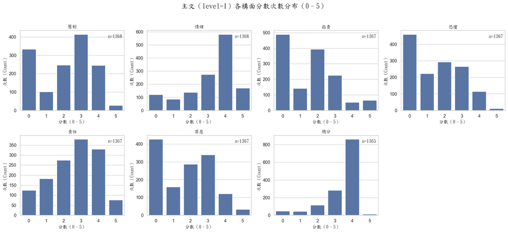

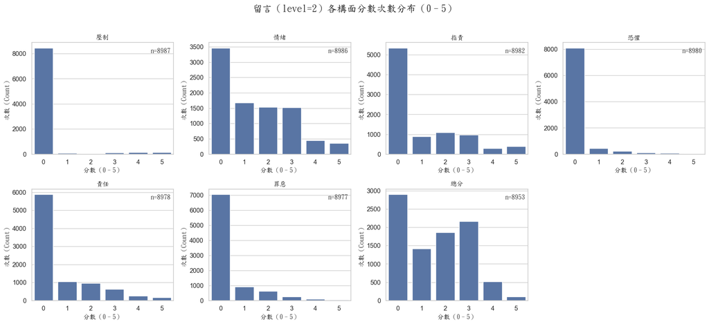

```python
import pandas as pd
import seaborn as sns
import matplotlib.pyplot as plt
from pathlib import Path

col_map = {
    'strategy_power': '壓制',
    'strategy_emotion': '情緒',
    'strategy_blame': '指責',
    'score_fear': '恐懼',
    'score_obligation': '責任',
    'score_guilt': '罪惡',
    'score_overall': '總分'
}
score_order = [0, 1, 2, 3, 4, 5]

sns.set(style="whitegrid", font_scale=1.05)

def _coerce_scores_0_5(df: pd.DataFrame) -> pd.DataFrame:
    """把分數欄位轉成可畫的 0–5 整數（會把不合法值變 NaN）。"""
    out = df.copy()
    for c in col_map.keys():
        # 轉數字（字串也能轉），不能轉的變 NaN
        out[c] = pd.to_numeric(out[c], errors="coerce")

        # 如果你分數本來就是整數，這行不影響；若是 0.0/1.0 也會變整數
        out[c] = out[c].round()

        # 只保留 0–5，其它丟掉避免干擾
        out.loc[~out[c].between(0, 5), c] = pd.NA

        # 轉成 pandas 的可空整數
        out[c] = out[c].astype("Int64")
    return out

def plot_and_save_big(df: pd.DataFrame, title_text: str, out_path: str | None = None):
    df = _coerce_scores_0_5(df)

    fig, axes = plt.subplots(2, 4, figsize=(18, 8))
    axes = axes.flatten()

    for i, (col, cname) in enumerate(col_map.items()):
        ax = axes[i]
        sns.countplot(
            data=df,
            x=col,
            order=score_order,
            ax=ax
        )
        ax.set_title(cname, fontproperties=winfont02)
        ax.set_xlabel("分數（0–5）", fontproperties=winfont02)
        ax.set_ylabel("次數（Count）", fontproperties=winfont02)
        ax.set_xticks(score_order)

        # 顯示該構面的有效樣本數（避免你看到空但其實是全 NaN）
        n_valid = df[col].notna().sum()
        ax.text(0.98, 0.95, f"n={n_valid}", transform=ax.transAxes,
                ha="right", va="top", fontproperties=winfont02)

    # 移除多餘 subplot
    fig.delaxes(axes[-1])

    fig.suptitle(title_text, fontproperties=winfont02, fontsize=18, y=1.02)
    plt.tight_layout()

    if out_path:
        out_path = Path(out_path)
        out_path.parent.mkdir(parents=True, exist_ok=True)
        fig.savefig(out_path, dpi=300, bbox_inches="tight")

    plt.show()
    plt.close(fig)

# 主文一張（可存檔）
plot_and_save_big(df_main, "主文（level=1）各構面分數次數分布（0–5）", "main_level1_count_grid.png")

# 留言一張（可存檔）
plot_and_save_big(df_reply, "留言（level=2）各構面分數次數分布（0–5）", "reply_level2_count_grid.png")
```

主文與留言在情緒勒索結構上呈現明顯差異：主文多為中高分、結構較完整之情緒壓力建構，而留言則以低分或非勒索內容為主，僅於特定互動情境下出現局部構面之情緒勒索表現

### confidence × overall

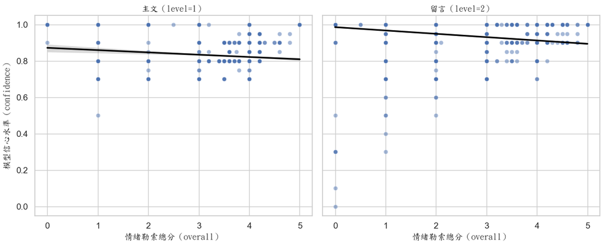

```python
import pandas as pd
import seaborn as sns
import matplotlib.pyplot as plt

sns.set(style="whitegrid", font_scale=1.1)

# ===== 1. 整理資料（確保型態） =====
def prep_df(df):
    out = df[["score_overall", "confidence"]].copy()
    out["score_overall"] = pd.to_numeric(out["score_overall"], errors="coerce")
    out["confidence"] = pd.to_numeric(out["confidence"], errors="coerce")
    return out.dropna(subset=["score_overall", "confidence"])

df_main_p = prep_df(df_main)
df_reply_p = prep_df(df_reply)

# ⚠️ 如果 confidence 是 0–100，取消下一行註解
# df_main_p["confidence"] /= 100
# df_reply_p["confidence"] /= 100

# ===== 2. 畫左右兩張子圖 =====
fig, axes = plt.subplots(1, 2, figsize=(12, 5), sharex=True, sharey=True)

# ---- 左：主文 ----
sns.scatterplot(
    data=df_main_p,
    x="score_overall",
    y="confidence",
    alpha=0.5,
    ax=axes[0]
)
sns.regplot(
    data=df_main_p,
    x="score_overall",
    y="confidence",
    scatter=False,
    color="black",
    ax=axes[0]
)

axes[0].set_title("主文（level=1）", fontproperties=winfont02)
axes[0].set_xlabel("情緒勒索總分（overall）", fontproperties=winfont02)
axes[0].set_ylabel("模型信心水準（confidence）", fontproperties=winfont02)

# ---- 右：留言 ----
sns.scatterplot(
    data=df_reply_p,
    x="score_overall",
    y="confidence",
    alpha=0.5,
    ax=axes[1]
)
sns.regplot(
    data=df_reply_p,
    x="score_overall",
    y="confidence",
    scatter=False,
    color="black",
    ax=axes[1]
)

axes[1].set_title("留言（level=2）", fontproperties=winfont02)
axes[1].set_xlabel("情緒勒索總分（overall）", fontproperties=winfont02)
axes[1].set_ylabel("")

plt.tight_layout()
plt.show()
```

主文（level=1）

留言（level=2）

- 高 overall（3–5）時，confidence 明顯集中在 0.9 以上
- 低 overall（0–1）時，confidence 分布較為分散（甚至有偏低的點）
- 趨勢線同樣呈現 輕微下降

## 看一下他裡面主要的策略分布

我這次覺得要以百分比的方式

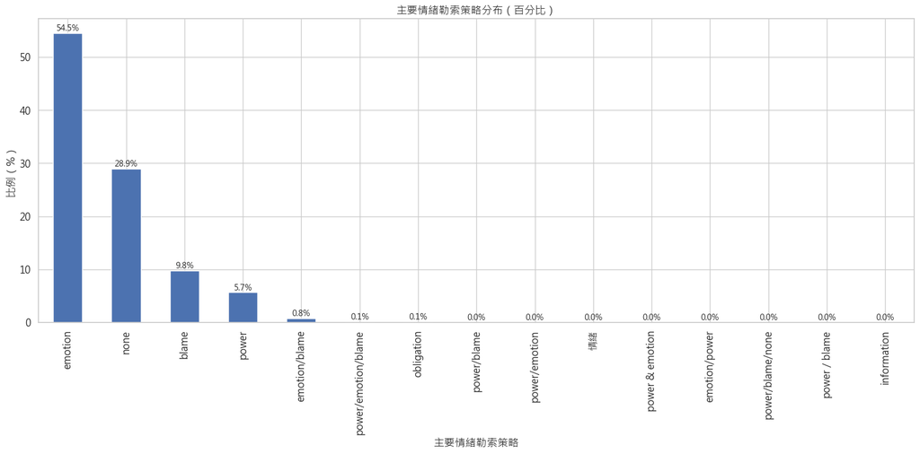

```python
import matplotlib.pyplot as plt

vc = (
    df_eda['main_strategy']
    .value_counts(normalize=True)
    .mul(100)
)

ax = vc.plot(kind='bar', figsize=(16,8))

ax.set_ylabel('比例（%）')
ax.set_xlabel('主要情緒勒索策略')
ax.set_title('主要情緒勒索策略分布（百分比）')

for p in ax.patches:
    ax.annotate(
        f"{p.get_height():.1f}%",
        (p.get_x() + p.get_width() / 2, p.get_height()),
        ha='center', va='bottom', fontsize=10
    )

plt.tight_layout()
plt.show()
```

大多數文字使用「情緒訴求（emotion）」策略  
指責（blame）與壓制（power）是次要策略

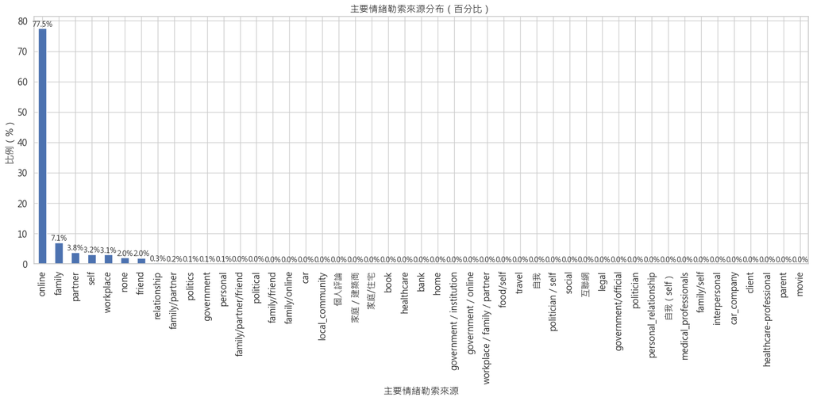

```python
import matplotlib.pyplot as plt

vc = (
    df_eda['pua_source']
    .value_counts(normalize=True)
    .mul(100)
)

ax = vc.plot(kind='bar', figsize=(16,8))

ax.set_ylabel('比例（%）')
ax.set_xlabel('主要情緒勒索來源')
ax.set_title('主要情緒勒索來源分布（百分比）')

for p in ax.patches:
    ax.annotate(
        f"{p.get_height():.1f}%",
        (p.get_x() + p.get_width() / 2, p.get_height()),
        ha='center', va='bottom', fontsize=10
    )

plt.tight_layout()
plt.show()
```